# The Final Project

Choose one of the following problems to proceed:

## Problem 1: Perform sentiment analysis on a movie review corpus created by scraping IMDb Webpages

- The starting point could be [this webpage](https://www.imdb.com/chart/moviemeter?sort=rk,asc&mode=simple&page=1).
- Collect user reviews (and ratings; note that some reviews may have no ratings) for 100 movies, 100 reviews per movie (with spoilers excluded; note that on each review page, there is a checkbox labeled “Hide Spoilers”).
- Sample 2500 positive reviews and 2500 negative reviews (For example, a movie receving a rating higher than 6 is considered positive or getting thumbs-up, while one with a rating less than 5 is negative or getting thumbs-down) to form a movie review corpus.
  - Note: the most noteworthy fact for review corpora collected from the Web is that the majority of reviews are highly positive, with 6-star to 10-star reviews. If you cannot find a sufficient number of negative reviews from your 10,000 reviews, report the imbalance of the distribution.
- Use list-based measures (use the `BING` or `AFINN` lexicon) to predict sentiments, and evaluate outcomes by contrasting them with actual ratings.
- Find 5 most commonly-used positive and negative words in the corpus. For each word, plot a graphic similar to the following one, which describes the extent to which a word affects the rating of the review where it appears ($w$ represents the word, while $c$ represents categories defined in terms of ratings). For instance, the point at rating 3 means that a review containing “disappoint” has probability 0.14 of receiving rating 3. This can be calculated by applying the *Bayes’ rule*

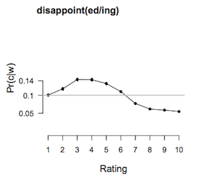

## Problem 2: Create a choropleth map for the House election results of the 2018 US midterm election

- Scrape data from [this website](https://www.bloomberg.com/graphics/2018-midterm-election-results/?view=H&filter=none).
- How to get map data for congressional districts:
  - Congressional districts include the areas from which people are elected to the U.S. House of Representatives and the areas with nonvoting delegates from state equivalents. After the apportionment of congressional seats among the states based on decennial census population counts, each state is responsible for establishing the boundaries of the congressional districts for the purpose of electing representatives. Each congressional district is to be as equal in population to all other congressional districts in a state as practicable.
  - Visit the webpage for [TIGER (short for Topologically Integrated Geographic Encoding and Referencing)/Line shapefiles](https://www.census.gov/geo/maps-data/data/tiger-line.html) from the US Census Bureau. Download the shaplefile for the 115th Congressional Districts.
  - The map data is store in a shapefile with extension .shp. To use it, we need to load it with `st_read()` in the `sf` package (tools for manipulating [simple feature objects](https://r-spatial.github.io/sf/articles/sf1.html)). You can read this [online tutorial](https://www.r-spatial.org/r/2018/10/25/ggplot2-sf.html) for more on drawing maps with `sf` and `ggplot2`.

```r
cd115 <- sf::st_read("path to the .shp file")
```

```r
str(cd115)
```

```
## Classes 'sf' and 'data.frame':   444 obs. of  13 variables:
##  $ STATEFP : Factor w/ 56 levels "01","02","04",..: 24 24 24 24 14 14 14 14 28 5 ...
##  $ CD115FP : Factor w/ 56 levels "00","01","02",..: 8 3 7 9 2 19 8 3 2 37 ...
##  $ GEOID   : Factor w/ 444 levels "0101","0102",..: 223 218 222 224 135 152 141 136 238 57 ...
##  $ NAMELSAD: Factor w/ 57 levels "Congressional District (at Large)",..: 52 13 51 53 2 11 52 13 2 31 ...
##  $ LSAD    : Factor w/ 5 levels "00","C1","C2",..: 3 3 3 3 3 3 3 3 3 3 ...
##  $ CDSESSN : Factor w/ 1 level "115": 1 1 1 1 1 1 1 1 1 1 ...
##  $ MTFCC   : Factor w/ 1 level "G5200": 1 1 1 1 1 1 1 1 1 1 ...
##  $ FUNCSTAT: Factor w/ 2 levels "F","N": 2 2 2 2 2 2 2 2 2 2 ...
##  $ ALAND   : num  8.66e+10 6.31e+09 7.46e+09 7.23e+10 6.69e+08 ...
##  $ AWATER  : num  5.06e+09 2.44e+08 4.06e+08 1.25e+10 2.07e+06 ...
##  $ INTPTLAT: Factor w/ 444 levels "-14.2668475",..: 431 417 424 434 348 285 360 336 338 113 ...
##  $ INTPTLON: Factor w/ 444 levels "-064.8903849",..: 301 273 285 274 232 256 226 228 313 369 ...
##  $ geometry:sfc_MULTIPOLYGON of length 444; first list element: List of 1
##   ..$ :List of 1
##   .. ..$ : num [1:37803, 1:2] -97.2 -97.2 -97.2 -97.2 -97.2 ...
##   ..- attr(*, "class")= chr  "XY" "MULTIPOLYGON" "sfg"
##  - attr(*, "sf_column")= chr "geometry"
##  - attr(*, "agr")= Factor w/ 3 levels "constant","aggregate",..: NA NA NA NA NA NA NA NA NA NA ...
##   ..- attr(*, "names")= chr  "STATEFP" "CD115FP" "GEOID" "NAMELSAD" ...
```

```r
head(cd115)
```

```
## Simple feature collection with 6 features and 12 fields
## geometry type:  MULTIPOLYGON
## dimension:      XY
## bbox:           xmin: -97.23909 ymin: 39.39567 xmax: -87.57311 ymax: 49.38436
## epsg (SRID):    4269
## proj4string:    +proj=longlat +datum=NAD83 +no_defs
##   STATEFP CD115FP GEOID                  NAMELSAD LSAD CDSESSN MTFCC
## 1      27      07  2707  Congressional District 7   C2     115 G5200
## 2      27      02  2702  Congressional District 2   C2     115 G5200
## 3      27      06  2706  Congressional District 6   C2     115 G5200
## 4      27      08  2708  Congressional District 8   C2     115 G5200
## 5      17      01  1701  Congressional District 1   C2     115 G5200
## 6      17      18  1718 Congressional District 18   C2     115 G5200
##   FUNCSTAT       ALAND      AWATER    INTPTLAT     INTPTLON
## 1        N 86581180363  5057706724 +46.5530202 -095.6759048
## 2        N  6314196469   243534838 +44.4789680 -092.8530418
## 3        N  7463332695   405721162 +45.3368069 -093.8520551
## 4        N 72279889700 12450296907 +47.2503395 -092.9638683
## 5        N   669233988     2069827 +41.5466708 -087.8357472
## 6        N 27235643868   383093290 +40.2271844 -090.0691183
##                         geometry
## 1 MULTIPOLYGON (((-97.23909 4...
## 2 MULTIPOLYGON (((-93.91131 4...
## 3 MULTIPOLYGON (((-94.64041 4...
## 4 MULTIPOLYGON (((-95.18322 4...
## 5 MULTIPOLYGON (((-88.13677 4...
## 6 MULTIPOLYGON (((-91.51297 4...
```

The meanings of the 12 fields of the simple feature object can be found in [section 3.5 of this pdf file](https://www2.census.gov/geo/pdfs/maps-data/data/tiger/tgrshp2017/TGRSHP2017_TechDoc_Ch3.pdf).

`ggplot2` provides a [set of `geom`, `stat`, and `coord`](https://ggplot2.tidyverse.org/reference/ggsf.html) to visualise simple feature objects. The following code creates the graphic representing congressional districts of Arizona and Minnesota.

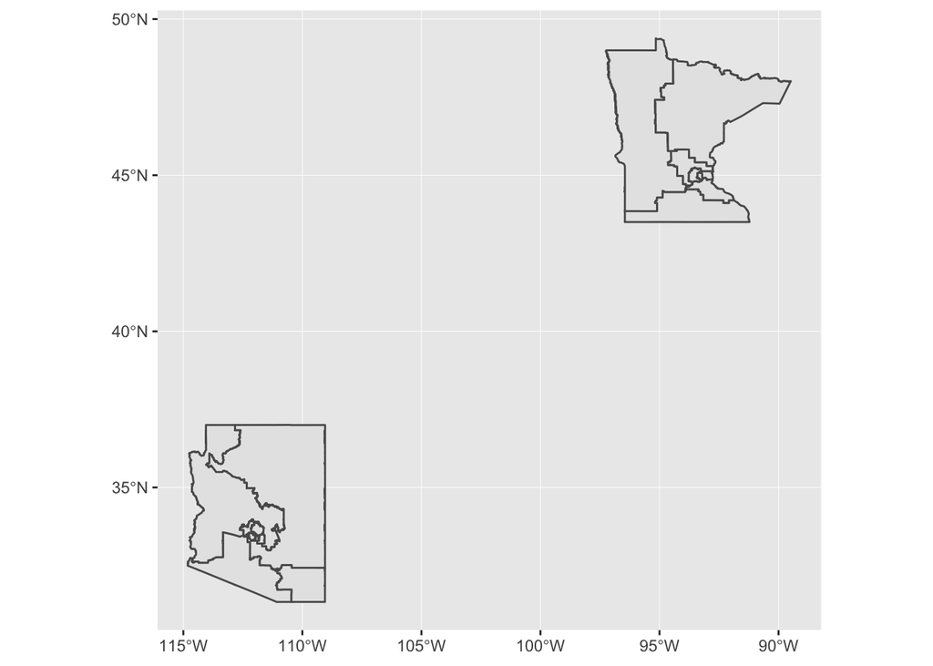

```r
cd115 %>% filter(STATEFP %in% c("27", "04")) %>% ggplot() + geom_sf()
```

- The most tricky part is to include an inset map for non-contiguous areas (Alaska and Hawaii) of the United States. An online tutorial that teaches you to do so can be found [here](https://www.r-spatial.org/r/2018/10/25/ggplot2-sf-3.html). For more on making maps with R, visit https://geocompr.robinlovelace.net/adv-map.html#inset-maps.

## Criteria for evaluating your submission

Your submission should be an R markdown file that wraps up your write-up and code, and a csv file containing the dataset you use. It will be evaluated based on the following criteria:

- Whether the interpretation is clear and in-depth. The write-up in the R markdown file should clearly explain the steps you take to perform the analyses, and accurately interpret the results, with appropriate caveats for what the technique can and cannot do. Visualize the results of your analyses whenever possible.
- Whether the code is reproducible (including the code for Web scraping), with necessarily detailed annotation.
- Whether the dataset created from Web scraping and used as the input to your analyses is present.

If your group faces a severe free rider problem, and if it cannot be addressed by your private efforts, please inform us by dropping me or Charles an email. Once it is verified, grade penalty will be exercised accordingly.

##### Submission Deadline: 11:59pm, Dec. 20th